# AGDS Report 1 - Phenology Modelling and Spatial Scaling

Nora Bisang

2025-12-23

## 1. Introduction

This exercize covers the improvement of a temperature-based growing degree day (GDD) phenology model as well as spatial upscaling. Phenological transition dates, which are derived from PhenoCam data are used to create a leaf out model. This is then applied spatially using DAYMET temperature data and compared to the MODIS MCD12Q2 phenology product.

## 2. Data and preprocessing

### Setup libraries

```r
library(appeears)
library(dplyr)
library(ggplot2)
library(geodata)
library(here)
library(htmlwidgets)
library(keyring)
library(leaflet)
library(lubridate)
library(MODISTools)
library(phenocamr)
library(sf)
library(terra)
library(tidyterra)
```

### 2.2 PhenoCam data and phenology extraction

The phenocamr R package uses the PhenoCam API to access the latest GCC time series and derive phenology using a threshold-based methodology. The phenocamr API call also downloads DAYMET data, which includes both daily minimum and maximum data.

```r
# download greenness time series,
# calculate phenology (phenophases),
# amend with DAYMET data
phenocamr::download_phenocam(
  site = "harvard$",
  veg_type = "DB",
  roi_id = "1000",
  daymet = TRUE,
  phenophase = TRUE,
  trim = 2022,
  out_dir = tempdir()
  )

harvard_phenocam_data <- readr::read_csv(
  file.path(tempdir(), "harvard_DB_1000_3day.csv"),
  comment = "#"
  )

# reading in harvard phenology only retaining
# spring (rising) phenology for the GCC 90th
# percentile time series
harvard_phenology <- readr::read_csv(
  file.path(
    tempdir(),
    "harvard_DB_1000_3day_transition_dates.csv"
    ),
  comment = "#"
) |>
  dplyr::filter(
    direction == "rising",
    gcc_value == "gcc_90"
  )
```

## 3. Growing Degree Day (GDD) phenology model

Growing degree days are defined as the cumulative sum of sum of daily mean temperatures above a specified threshold (T0 , most commonly for deciduous vegetation T0= 5°C). The leaf-out is assumed when a critical accumulation of GDD is reached.

### 3.1 Model formulation

```r
harvard_temp <- harvard_phenocam_data |>
  group_by(year) |>
  dplyr::mutate(
    tmean = (tmax..deg.c. + tmin..deg.c.)/2
  ) |>
  dplyr::mutate(
    date = as.Date(date),
    gdd = cumsum(ifelse(tmean >= 5, tmean - 5, 0))
  ) |>
  dplyr::select(
    date,
    year,
    tmean,
    gdd
  ) |>
  ungroup()

# convert the harvard phenology data and only
# retain required data
harvard_phenology <- harvard_phenology |>
  mutate(
    doy = as.numeric(format(as.Date(transition_25),"%j")),
    year = as.numeric(format(as.Date(transition_25),"%Y"))
  ) |>
  select(
    year,
    doy,
    transition_25,
    threshold_25
    )
```

### 3.2 Model implementation

```r
gdd_model <- function(temp, par) {
  # split out parameters from a simple
  # vector of parameter values
  temp_threshold <- par[1]
  gdd_crit <- par[2]

  # accumulate growing degree days for
  # temperature data
  gdd <- cumsum(ifelse(temp > temp_threshold, temp - temp_threshold, 0))

  # figure out when the number of growing
  # degree days exceeds the minimum value
  # required for leaf development, only
  # return the first value
  doy <- unlist(which(gdd >= gdd_crit)[1])

  return(doy)
}
```

### 3.3 Model verification

Running the model on the original 2010 data with the previously observed values and parameters. (first evaluation for the year 2010 to verify that calculated parameter values reproduce the observed leaf-out date)

```r
# filter out the year 2010,
# removing the filter would run the
# model for all years
prediction <- harvard_temp |>
  dplyr::filter(
    year == 2010
  ) |>
  group_by(year) |>
  summarize(
    pred = gdd_model(
      temp = tmean,
      par = c(5, 130.44)
    )
  )

print(prediction)
```

```
## # A tibble: 1 × 2
##    year  pred
##   <dbl> <int>
## 1  2010   114
```

## 4. Model calibration and optimization

### 4.1 Function

Calibration of parameters with minimizing the root mean squared error between observed and predicted leaf-out dates over years.

```r
# run model and compare to true values
# returns the RMSE
rmse_gdd <- function(par, data) {

  # split out data
  drivers <- data$drivers
  validation <- data$validation


  predictions <- drivers |>
    group_by(year) |>
    summarise(
      predictions = gdd_model(
        temp = tmean,
        par = par
      )
    )

  predictions <- left_join(predictions, validation, by = "year")

  rmse <- predictions |>
    summarise(
      rmse = sqrt(mean((predictions - doy)^2, na.rm = TRUE))
    ) |>
    pull(rmse)

  # return rmse value
  return(rmse)
}
```

### 4.2 Parameter optimisation

The parameter “range” was constrained to ranges that are physiologically plausible to reduce computation time/cost and to avoid unrealistic calculations.

Optimization routine: the optimal parameters for the temperature threshold and number of accumulation days will be determined.

```r
# starting model parameters
par = c(0, 130)

# limits to the parameter space
lower <- c(-10,0)
upper <- c(45,500)

# data needs to be provided in a consistent
# single data file, a nested data structure
# will therefore accept non standard data formats
data <- list(
  drivers = harvard_temp,
  validation = harvard_phenology
  )

# optimize the model parameters
optim_par = GenSA::GenSA(
 par = par,
 fn = rmse_gdd,
 lower = lower,
 upper = upper,
 control = list(
   max.call = 4000
   ),
 data = data
)$par
```

### 4.3 Calibrated model predictions

These optimal parameters can now be plugged back into the model and run across all available years.

```r
# run the model for all years
# to get the phenology predictions
predictions <- harvard_temp |>
  group_by(year) |>
  summarize(
   prediction = gdd_model(
    temp = tmean,
    par = optim_par
  )
  )
```

## 5. Spatial scaling using DAYMET temperature data

A region around Boston in the eastern United States will be used, defined by the coordinates -72 to -70 East, and 42 to 44 North. The DAYMET raster data to scale the results spatially will be used.

### 5.1 DAYMET data acquisition

The data is downloaded manually from github. Provided by geco-bern Fabian Alexander Bernhard.

```r
library(ncdf4)
dest_file <- here::here("data-raw", "DAYMET_2012_aid0001.nc")

download.file(
    "https://github.com/fabern/handfull_of_pixels/raw/refs/heads/main/data/DAYMET.004_2012/DAYMET.004_1km_aid0001.nc",
    destfile = dest_file,
    mode = "wb"   # important for binary files like .nc
  )
r1 <- terra::rast(dest_file)  # Load with terra
terra::crs(r1) <- "epsg:4326" # Assign CRS
```

### 5.2 Temperature preprocessing

Definition of names and subsetting of the first 180 days for reduction of the memory footprint of the calculations.

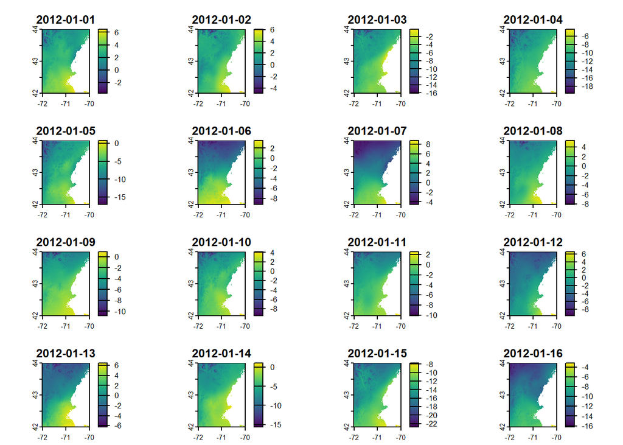

```r
 # Calculate the daily mean values based on 'tmin' and 'tmax'
library(terra)
mean_layer <- terra::mean(r1["tmax"],
                            r1["tmin"])
  # fix the variable naming
varnames(mean_layer) <- "tmean"
names(mean_layer) <- gsub("tmax","tmean",names(mean_layer))

 # subset to first 180 days
  ma_nh_temp <- terra::subset(
    mean_layer,
    1:180
  )

terra::plot(mean_layer)
```

### 5.3 Spatial appliance of the GDD model

Appliance of the model to the raster using the the terra::app() function the growing degree day model gdd_model()

```r
predicted_phenology <- terra::app(
  ma_nh_temp,
  fun = gdd_model,
  par = optim_par
)
```

### 5.4 Spatial visualisation

Will result in an interactive map of the spatially scaled optimized growing degree model, including the greater Boston area in the south-east to the White Mountains in the north-west.

```r
pal <- colorNumeric(
  "magma",
  values(predicted_phenology),
  na.color = "transparent"
  )

# build the leaflet map
leaflet() |>
  addProviderTiles(providers$Esri.WorldImagery, group = "World Imagery") |>
  addProviderTiles(providers$Esri.WorldTopoMap, group = "World Topo") |>
  addRasterImage(
    predicted_phenology,
    colors = pal,
    opacity = 0.8,
    group = "Phenology model results"
    ) |>
  addLayersControl(
    baseGroups = c("World Imagery","World Topo"),
    position = "topleft",
    options = layersControlOptions(collapsed = FALSE),
    overlayGroups = c("Phenology model results")
    ) |>
  addLegend(
    pal = pal,
    values = values(predicted_phenology),
    title = "DOY")
```

[interactive chart not shown]

## 6. Model improvement and evaluation

### 6.1 Conceptual model improvements- Question 1

How can you improve the model used to regionally scale the results in Chapter 6? Provide at least three ways to improve the model used. Implement at least one of these methods

### 6.1a:

Cross-validation across years (temporal) and/or across space (spatial). This would allow assessment of the generalizability of the GDD model. If the model predicts well over different validation folds, this suggests that it captures true biological relationships rather than noise (-> Overfitting!). And thus would improve robustness and reliability of the model.

### 6.1b:

Smoothing of the temperature (with eg Savitzky–Golay) A smoothing window (of eg. 3days) could be used before accumulation of GDD. This would make our GDD less sensitive to isolated single day warm or cold spikes, which are not very likely to shift buddburst substantially, which would reduce variance caused by noise in early months of the year. At the same time the temperature rise dynamics would still be preserved. Further, smoothed temperature time series would lead to smoother residuals, which then would make downstream regression or kNN corrections more stable and less sensitive to random variance.

### 6.1c:

Our GDD model assumes that each day with Temperature mean >5°C contributes equally to plant development, in reality though, plant development could also accelerate, be slower or plateau. We could apply a machine learning approach such as K-Nearest Neighbour (As in chapter 10), which is really good at pattern recognition and non-linear relationships. These would be beneficial in our model as especially when not only cumulative growing days matter but the climate variability patterns have influence on the (like frost events or really warm periods) it would be able to learn the relationship from the data with no need for an assumption about the form.

### 6.2 Implementation of temperature smoothing

Smoothing with the Savitzky-Golay-Filter used in chapter 5.3.

```r
#install.packages("signal")
library(signal)

 NA %in% harvard_temp
```

```
## [1] FALSE
```

```r
harvard_temp.smoothed <- harvard_temp %>%
  group_by(year) %>%
  mutate(
    tmean_smooth = signal::sgolayfilt(tmean, p = 3, n = 5))  # smaller n for daily data

#usually for GDD calculations a window of n=3-7 is used. I choose a 5-day moving window (2 days before and 2 after), which smooths out random daily noise but keeps the overall warming trend intact.
#Polynomial of 3 matches, as it can capture slight “S”-shapes, which are typical in temperature curves, without overfitting.


harvard_temp.smoothed <- harvard_temp.smoothed %>%
  mutate(
    gdd = cumsum(ifelse(tmean_smooth >= 5, tmean_smooth - 5, 0))
  )
```

Comparison of the RMSE Smoothened Temperatures vs unsmoothened

```r
# Compare RMSE before and after smoothing
rmse_original <- rmse_gdd(optim_par, data)

#overwriting tmean with smoothened for function
harvard_temp.smoothed <- harvard_temp.smoothed |>
  mutate(tmean = tmean_smooth)


rmse_smoothed <- rmse_gdd(
  optim_par,
  list(
    drivers = harvard_temp.smoothed,
    validation = harvard_phenology
  )
)

rmse_original
```

```
## [1] 4.389381
```

```r
rmse_smoothed
```

```
## [1] 4.704608
```

The unsmoothed GDD model achieved an RMSE of 4.39 days, while the model using smoothed temperature inputs achieved a slightly higher RMSE of 4.70 days. This indicates that temperature smoothing does not improve, but rather slightly degrades, the performance for leaf-out timing of this threshold-based GDD. One possible explanation is that also short-term warming in early spring contribute meaningfully to heat accumulation and biological development. And as smoothing dampens these signals, it delays the day of threshold reaching. Short: the results indicate that the original model is already robust and that temperature smoothing is not beneficial in this context.

## 7 Comparison with MODIS phenology - Exercize 3

### 7.1 Spatial and Statistical Comparison

Statistically and Spatially compare the results with the MODIS MCD12Q2 phenology product.

### 7.2 Patterns

Describe why you might or might not see the same patterns

### 7.3 Special case of 2010

Consider that 2010 was a ‘special’ year for the north east of the US

### 7.1 Spatial and Statistical Comparison

Spatial comparison showing the DOY difference between the prediction and the MODIS data.

```r
# download SRTM data
geodata::elevation_3s(
    lat = 43,
    lon = -71,
    path = tempdir()
  )
```

```
## class       : SpatRaster
## size        : 6000, 6000, 1  (nrow, ncol, nlyr)
## resolution  : 0.0008333333, 0.0008333333  (x, y)
## extent      : -75, -70, 40, 45  (xmin, xmax, ymin, ymax)
## coord. ref. : +proj=longlat +datum=WGS84 +no_defs
## source      : srtm_22_04.tif
## name        : srtm_22_04
```

```r
dem_file <- file.path(tempdir(), "elevation", "srtm_22_04.tif")
# Loading of raster
dem <- rast(dem_file)
# Check if worked or no
dem
```

```
## class       : SpatRaster
## size        : 6000, 6000, 1  (nrow, ncol, nlyr)
## resolution  : 0.0008333333, 0.0008333333  (x, y)
## extent      : -75, -70, 40, 45  (xmin, xmax, ymin, ymax)
## coord. ref. : lon/lat WGS 84 (EPSG:4326)
## source      : srtm_22_04.tif
## name        : srtm_22_04
```

```r
crs(dem)
```

```
## [1] "GEOGCRS[\"WGS 84\",\n    ENSEMBLE[\"World Geodetic System 1984 ensemble\",\n        MEMBER[\"World Geodetic System 1984 (Transit)\"],\n        MEMBER[\"World Geodetic System 1984 (G730)\"],\n        MEMBER[\"World Geodetic System 1984 (G873)\"],\n        MEMBER[\"World Geodetic System 1984 (…
```

```r
# download and save phenology data
phenology <- MODISTools::mt_subset(
  product = "MCD12Q2",
  lat = 43,            #midpoint of longitude/ latitude
  lon = -71,
  band = "Greenup.Num_Modes_01",
  start = "2012-01-01",
  end = "2012-12-31",
  km_lr = 100,
  km_ab = 100,
  site_name = "Boston",
  internal = TRUE,
  progress = FALSE
)
```

Conversion of the integer values, counted from 1970, to day-of-year values. Only considering phenological events in the first 200 days of the year.

```r
# screening of data
phenology <- phenology |>
  mutate(
    value = ifelse(value > 32656, NA, value),
    value = as.numeric(format(as.Date("1970-01-01") + value, "%j")),
    value = ifelse (value < 200, value, NA)
  )
```

Conversion of tidy data to a geospatial (terra SpatRast) format

```r
phenology_raster <- MODISTools::mt_to_terra(
  phenology,
  reproject = TRUE
)
```

Visualization

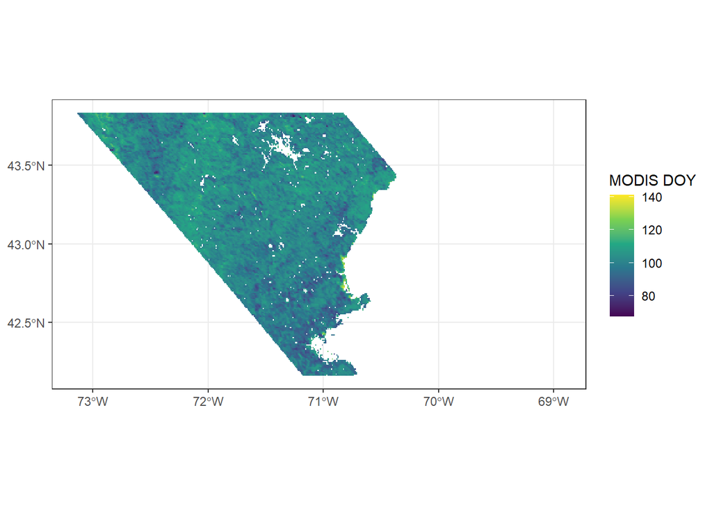

```r
# Ensure rasters align
predicted_resampled <- terra::resample(predicted_phenology, phenology_raster, method = "near")

# Pixel-wise difference btw. DOY predicted by our model and the observed DOY from MODIS:
difference <- predicted_resampled - phenology_raster

# 1 Plot from MODIS observations
ggplot() +
  geom_spatraster(data = phenology_raster) +
  scale_fill_viridis_c(name = "MODIS DOY", na.value = NA) +
  theme_bw()
```

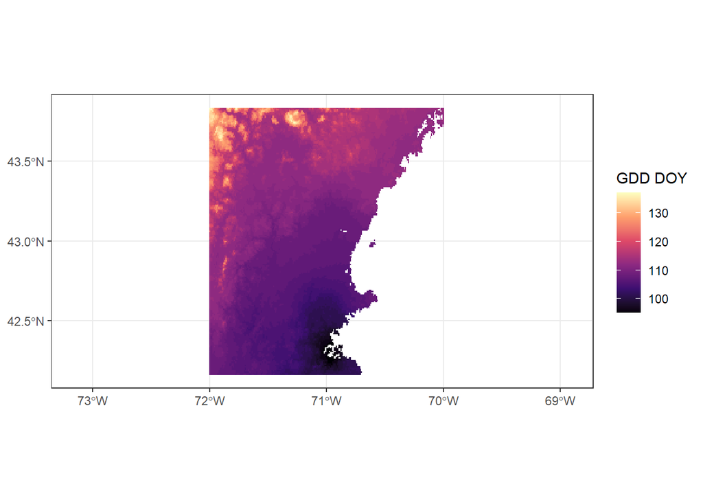

```r
# 2 Plot of the  GDD predictions
ggplot() +
  geom_spatraster(data = predicted_resampled) +
  scale_fill_viridis_c(name = "GDD DOY", na.value = NA, option = "magma") +
  theme_bw()
```

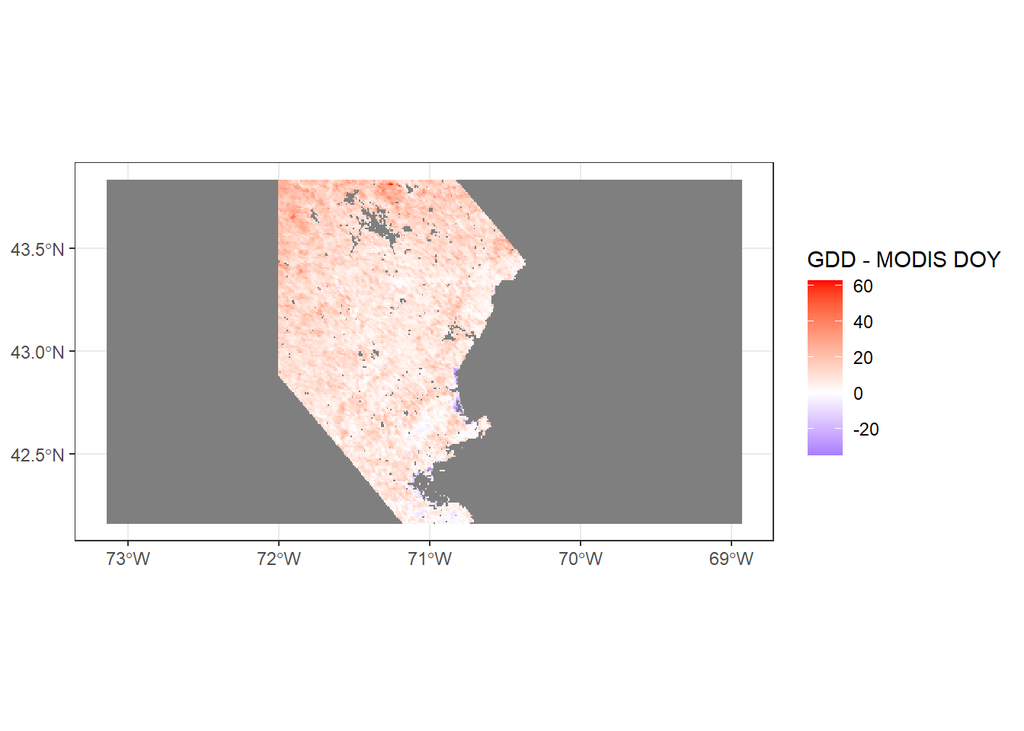

```r
# 3 Plot of difference (GDD - MODIS)
ggplot() +
  geom_spatraster(data = difference) +
  scale_fill_gradient2(low = "blue", mid = "white", high = "red", midpoint = 0,
                       name = "GDD - MODIS DOY") +
  theme_bw()
```

Statistical comparison that shows that the DOY differ between the prediction of the Model and the MODIS data.

```r
df <- na.omit(data.frame(
  MODIS = values(phenology_raster),
  GDD = values(predicted_resampled)
))


colnames(df) <- c("MODIS", "GDD")

cor(df$MODIS, df$GDD, use = "complete.obs") # 0.3886199
```

```
## [1] 0.3886199
```

```r
mean(df$GDD - df$MODIS, na.rm = TRUE) #9.973585
```

```
## [1] 9.973585
```

Spatial comparison (pixelwise) between the GDD phenology predictions and the MODIS observations shows moderate positive correlation with r = 0.39. THis indicates that the model captures larger-scale spatial gradients in phenology. Both datasets show climatic gradients related to latitude and difference in temperature from coast to inland. However, the model predicts leaf-out on average 9.97 days later than observed by MODIS, which could be due to systematic positive bias. Reasons for that could be: differences in phenological definitions, spatial resolution, vegetation heterogeneity, as well as the possibility of MODIS detecting canopy greening earlier than temperature-based leaf-out thresholds.

### 7.2 Patterns

Similar spatial patterns are expected because both approaches are somehow linked to temperature: directly in the GDD model through accumulated mean temperature, and indirectly in the MODIS observations through temperature-driven vegetation greening. Still, several factors can lead to differences between the two products. As MODIS does not measure temperature but detects changes in surface reflectance, it can be influenced by cloud cover, snow, and sensor related noise. Further, the GDD model assumes homogeneous vegetation responses and does not account for heterogeneity in species composition, microclimate and topography. Differences in spatial resolution between the DAYMET-driven model and the MODIS observations could further contribute to mismatches, particularly in heterogeneous landscapes.

### 7.3 Special case of 2010

```r
library(lubridate)
harvard_temp <- harvard_temp %>%
  mutate(doy = yday(date))   # create day-of-year column


spring_summary <- harvard_temp %>%
  dplyr::mutate(doy = lubridate::yday(date)) %>%   # DOY existing
  dplyr::filter(doy >= 60 & doy <= 120) %>%        # explicitly dplyr
  dplyr::group_by(year) %>%
  dplyr::summarize(
    mean_temp = mean(tmean, na.rm = TRUE),
    gdd_cum = sum(ifelse(tmean >= 5, tmean - 5, 0)),
    .groups = "drop"
  )

spring_summary
```

```
## # A tibble: 16 × 3
##     year mean_temp gdd_cum
##    <dbl>     <dbl>   <dbl>
##  1  2008     2.86    99.1
##  2  2009     4.10   118.
##  3  2010     6.31   150.
##  4  2011     3.10    84.1
##  5  2012     6.03   159.
##  6  2013     2.89    74.5
##  7  2014     0.551   51.7
##  8  2015     0.57    49.2
##  9  2016     4.43    93.6
## 10  2017     2.74   120.
## 11  2018     1.78    42.3
## 12  2019     3.34   115.
## 13  2020     3.83    43.2
## 14  2021     4.64   144.
## 15  2022     3.87    76.5
## 16  2023     1.29     2.72
```

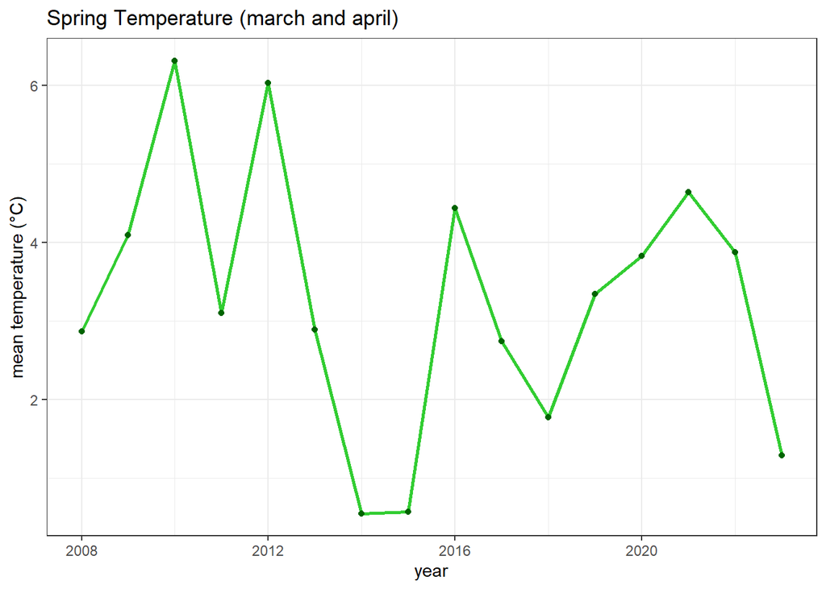

```r
#here as a visualization to see that temperature in 2010 was exceptionally warm (as was in 2012)
ggplot(spring_summary, aes(x = year)) +
  geom_line(aes(y = mean_temp), linewidth = 1, color = "limegreen") +
  geom_point(aes(y = mean_temp), color = "darkgreen") +
  labs(title = "Spring Temperature (march and april)",
       x = "year", y = "mean temperature (°C)") +
  theme_bw()
```

2010 was a special year as the DOY for leaf-out was earlier than usual. Leaf-out requires the accumulation of a certain amount of heat (GDD), so warmer springs reach the threshold sooner and thus result in earlier greening up. This indicates a warmer spring than normal. The calculated GDD accumulation cover early spring period (DOY 60–120) as I expect the biologically relevant window for bud development to lie in these days. Visible in the summary and plot are higher GDD values in 2010 and 2012 which indicate earlier spring warming, leading to earlier phenology and thus earlier DOY for budd-out. In the mean temperature March-April is well visible that mean temperatures indeed were exceptionally high.